# Modelowanie rynków finansowych - własności danych śróddziennych

Karol Doliński

Informatyka i Ekonometria

# 1 Wprowadzenie

Tematem niniejszego projektu jest zbadanie własności danych śróddziennych. Zwrócona zostanie uwaga na intensywność obrotu akcjami wybranych spółek giełdowych na przestrzeni sesji giełdowej oraz sprawdzone zostanie występowanie śróddziennej sezonowości zmienności wraz z ewentualnym zaproponowaniem stosunkowo prostej metody do usuwania tego zjawiska.

Wykorzystane w pracy dane zostały pobrane w dniu 15.10.2022 roku ze strony [Stooq](https://stooq.pl/) i dotyczą okresu od 26 sierpnia 2022 roku do 14 października 2022 roku. Zbiór danych dotyczy wartości zamknięcia dla dwóch spółek z indeksu WIG20: PGE i PGN (dane pięciominutowe). Dane 5-minutowe przedstawiają wartości zamknięcia od godziny 09:00 do 16:45.

W przypadku danych 5-minutowych możliwe są sytuacje, iż w jednym okresie 5-minutowym nie dojdzie do handlu papierami wartościowymi. W takim wypadku liczba wolumenów w zbiorze danych dla danego okresu jest równa 0, a wartości zamknięcia nie podaje się. W takich przypadkach zdecydowano się uzupełnić brakujące wartości pierwszymi je poprzedzającymi, które są niepuste.

Stopa zwrotu jest wskaźnikiem finansowym, miarą ryzyka danego przedsięwzięcia czy inwestycji. Na podstawie danych obliczono logarytmiczne stopy zwrotu:

$$R_{t} =
ln(\frac{C_t}{C_{t-1}}),$$

gdzie:

$C_{t}$ – cena zamknięcia $t$

$C_{t-1}$ – cena zamknięcia $t-1$

$t$ - jedna jednostka czasu, tj. dzień i godzina ze zbioru {2022-08-26 09:00, 2022-08-26 09:05, …, 2022-10-14 16:45}

Przed przystąpieniem do dalszej analizy zdecydowano się usunąć z uzyskanego szeregu czasowego stopy zwrotu *overnight*, czyli takie obliczone jako różnica logarytmu wartości zamknięcia z godziny 16:45 z dnia $i-1$ i logarytmu wartości zamknięcia z godziny 09:00 z dnia $i$ (uwzględniając tylko dni otwarcia giełdy).

```r
data_preprocessing <- function(x){
  x <- as_tibble(x[c("X.DATE.", "X.TIME.", "X.CLOSE.", "X.VOL.")])
  colnames(x) <- c("Date", "Time", "Close", "Volumen")
  x$Time <- str_pad(x$Time, 6, pad="0", side = "left")
  x <- x %>% mutate(DateTime = paste(Date, Time, sep = " "))
  x$DateTime <- ymd_hms(x$DateTime)
  x$Date <- ymd(x$Date)

  date_min <- paste0(as.character(min(x$Date)), " 09:00:00")
  date_max <- paste0(as.character(max(x$Date)), " 17:00:00")
  rates <- as_tibble(seq(ymd_hms(date_min), ymd_hms(date_max), by = 5*60))
  rates <- rates %>% filter(wday(value, week_start = getOption("lubridate.week.start", 1)) %in% c(1:5))
  rates <- rates %>% filter((hour(rates$value) * 60 + minute(rates$value) >= 9*60) & (hour(rates$value) * 60 + minute(rates$value) <= 16*60+45))
  colnames(rates) <- c("DateTime")

  rates <- left_join(rates, x, by = "DateTime")
  rates$Date <- as_date(rates$DateTime)
  rates$Time <- str_sub(as.character(rates$DateTime), -8, -1)
  rates$Close <- na.locf(rates$Close)
  rates$Volumen <- replace_na(rates$Volumen, 0)
  rates["Rate"] <- log(rates$Close / lag(rates$Close))
  rates$Time <- str_sub(as.character(rates$DateTime), -8, -4)

  return(rates)
}

rates_pge <- data_preprocessing(pge) %>% filter(hour(DateTime) * 60 + minute(DateTime) != 9*60)
rates_pgn <- data_preprocessing(pgn) %>% filter(hour(DateTime) * 60 + minute(DateTime) != 9*60)
```

# 2 Intensywność obrotu akcjami

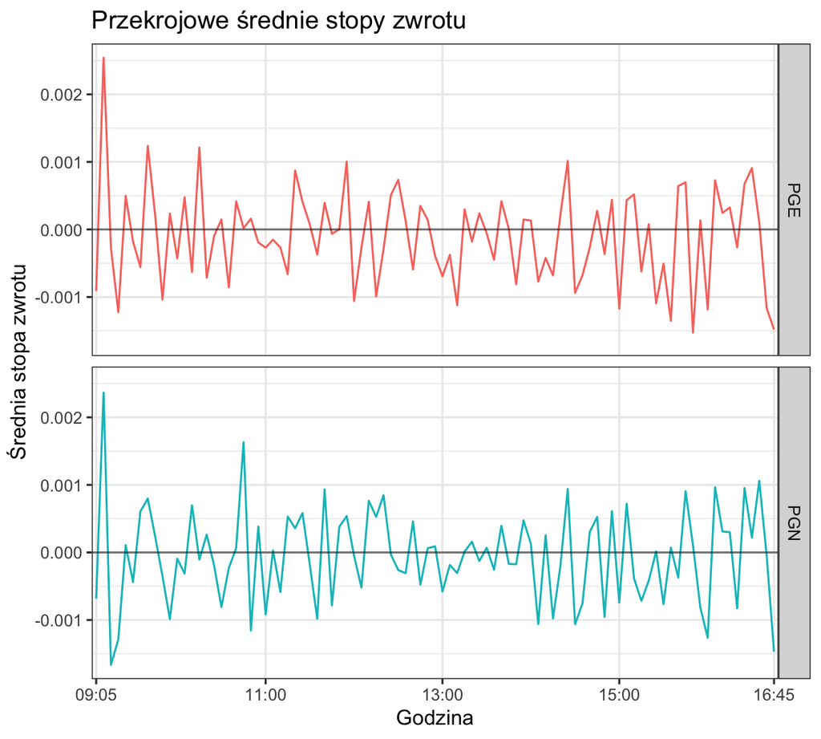

```r
mean_rates_pge <- rates_pge %>%
  group_by(Time) %>%
  summarize(Mean = mean(Rate))
mean_rates_pge["name"] <- 'PGE'

mean_rates_pgn <- rates_pgn %>%
  group_by(Time) %>%
  summarize(Mean = mean(Rate))
mean_rates_pgn["name"] <- 'PGN'

mean_rates <- rbind(mean_rates_pge, mean_rates_pgn)

mean_rates %>%
  ggplot(aes(x = Time, y = Mean, group = name, color = name)) +
  geom_line() +
  ggtitle("Przekrojowe średnie stopy zwrotu") +
  xlab("Godzina") +
  ylab("Średnia stopa zwrotu") +
  labs(color="Spółka") +
  geom_hline(yintercept=0, linetype="solid", color = "black", alpha=0.5) +
  scale_x_discrete(breaks = c('09:05', '11:00', '13:00', '15:00', '16:45')) +
  theme_bw() +
  theme(legend.position = "none") +
  facet_grid(factor(name)~.)
```

Wyznaczając średni zlogarytmowany wolumen obrou zdecydowano się dodać do każdej obserwacji po 1 jednostce. Nie wpłynie to w żaden istotny sposób na wynik i wyciągnięte wnioski, a pozwoli uniknąć sytuacji kiedy takiej średniej nie można byłoby wyznaczyć (gdyby w jakimkolwiek okresie 5-minutowym nie było żadnej transakcji, wówczas liczba wolumenów byłaby równa 0, a $ln(0) = -\infty$). Zlogarytmowanie ma na celu zmniejszenie wpływu obserwacji odstających.

Średni wolumen obrotu dla obu badanych spółek znajduje się przez większość czasu trwania sesji na stałym poziomie. Największy wzrost wolumenu obrotu następuje pod koniec notowań danego dnia – co jest raczej zjawiskiem zauważalnym dla zdecydowanej większości spółek akcyjnych. Większa liczba wolumenów jest przedmiotem handlu również na początku sesji giełdowej, chociaż dla spółek PGE i PGN nie są to drastycznie różne wartości średniego wolumenu obrotu w porównaniu do handlu w ciągu całego dnia.

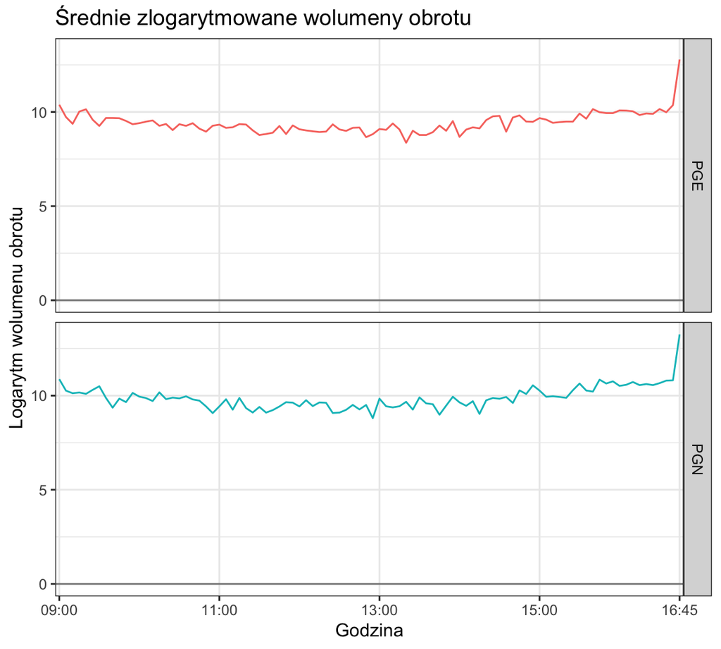

```r
mean_volumen_pge <- data_preprocessing(pge) %>%
  group_by(Time) %>%
  summarize(Mean = mean(log(Volumen+1)))
mean_volumen_pge["name"] <- 'PGE'

mean_volumen_pgn <- data_preprocessing(pgn) %>%
  group_by(Time) %>%
  summarize(Mean = mean(log(Volumen+1)))
mean_volumen_pgn["name"] <- 'PGN'

mean_volumen <- rbind(mean_volumen_pge, mean_volumen_pgn)

mean_volumen %>%
  ggplot(aes(x = Time, y = Mean, group = name, color = name)) +
  geom_line() +
  ggtitle("Średnie zlogarytmowane wolumeny obrotu") +
  xlab("Godzina") +
  ylab("Logarytm wolumenu obrotu") +
  labs(color="Spółka") +
  geom_hline(yintercept=0, linetype="solid", color = "black", alpha=0.5) +
  scale_x_discrete(breaks = c('09:00', '11:00', '13:00', '15:00', '16:45')) +
  theme_bw() +
  theme(legend.position = "none") +
  facet_grid(factor(name)~.)
```

# 3 Sezonowość zmienności

Następnym etapem pracy było zbadanie, czy w analizowanym okresie 5-minutowe stopy zwrotu akcji spółek PGE i PGN charakteryzowały się sezonową zmiennością. Jako przyczyny występowania śróddziennej sezonowości zmienności można wymienić:

- harmonogram sesji,
- wpływ otwarcia i/lub zamknięcia innych rynków,
- publikacje istotnych z punktu widzenia rynku lub danej spółki informacji.

Skutkiem występowania śróddziennej sezonowości zmienności jest między innymi zniekształcona autokorelacja.

Wykresy średnich z wartości bezwzględnych stóp zwrotu obu analizowanych spółek wskazują, iż największa zmienność występuje w pierwszej i ostatniej godzinie sesji. Najmniejsza, rzędu 0,002, występuje w godzinach od 11:00 do 14:00. Na tej podstawie można wnioskować o występowaniu dziennej sezonowości zmienności.

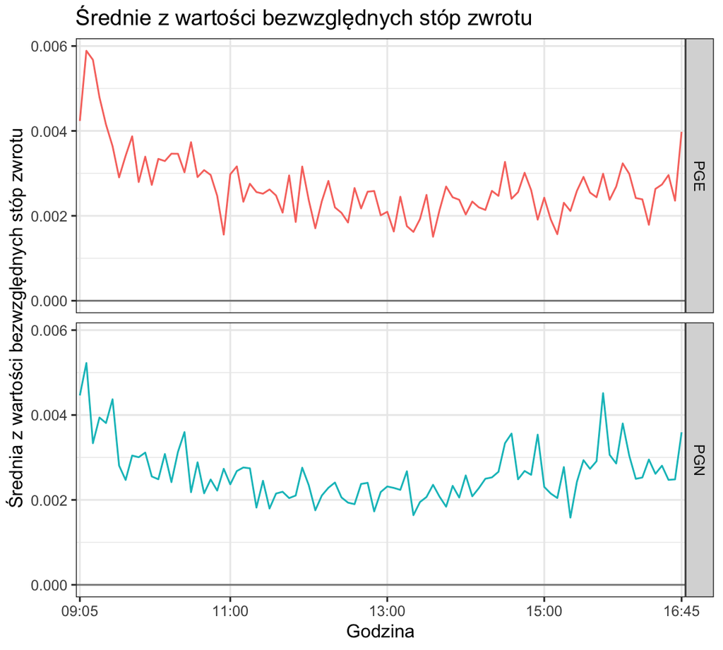

```r
mean_rates_abs_pge <- rates_pge %>%
  group_by(Time) %>%
  summarize(Mean = mean(abs(Rate)))
mean_rates_abs_pge["name"] <- 'PGE'

mean_rates_abs_pgn <- rates_pgn %>%
  group_by(Time) %>%
  summarize(Mean = mean(abs(Rate)))
mean_rates_abs_pgn["name"] <- 'PGN'

mean_rates_abs <- rbind(mean_rates_abs_pge, mean_rates_abs_pgn)

mean_rates_abs %>%
  ggplot(aes(x = Time, y = Mean, group = name, color = name)) +
  geom_line() +
  ggtitle("Średnie z wartości bezwzględnych stóp zwrotu") +
  xlab("Godzina") +
  ylab("Średnia z wartości bezwzględnych stóp zwrotu") +
  labs(color="Spółka") +
  geom_hline(yintercept=0, linetype="solid", color = "black", alpha=0.5) +
  scale_x_discrete(breaks = c('09:05', '11:00', '13:00', '15:00', '16:45')) +
  theme_bw() +
  theme(legend.position = "none") +
  facet_grid(factor(name)~.)
```

Następnie zbadano autokorelację wartości bezwzględnych stóp zwrotu. Na początku warto zauważyć, iż jeden dzień sesji to 93 okresy 5-minutowe (od 9:00 do 16:45). Widać pewną powtarzalność co taki okres. Najwyższe piki są dla początkowych opóźnień, następnie dla opóźnienia w okolicach 93 okresu i jego wielokrotności. Właściwie można mówić o następującym zjawisku, iż wartość funkcji ACF osiąga najwyższe wartości dla początkowych opóźnień, następne te wartości spadają by z powrotem wzrosnąć i osiągnąć szczyt w okolicach 93 opóźnienia. Zjawisko to się powtarza, z tym, że dla spółki PGE wydaje się ono bardziej wygaszać z upływem opóźnień.

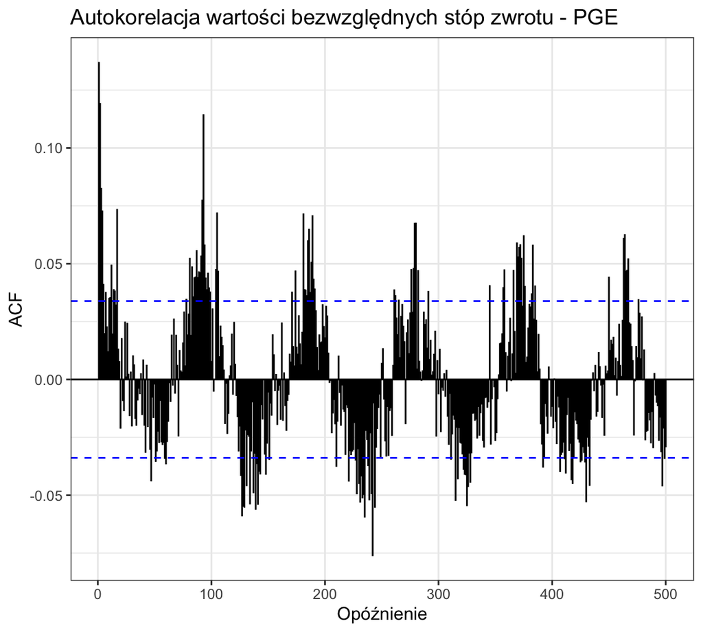

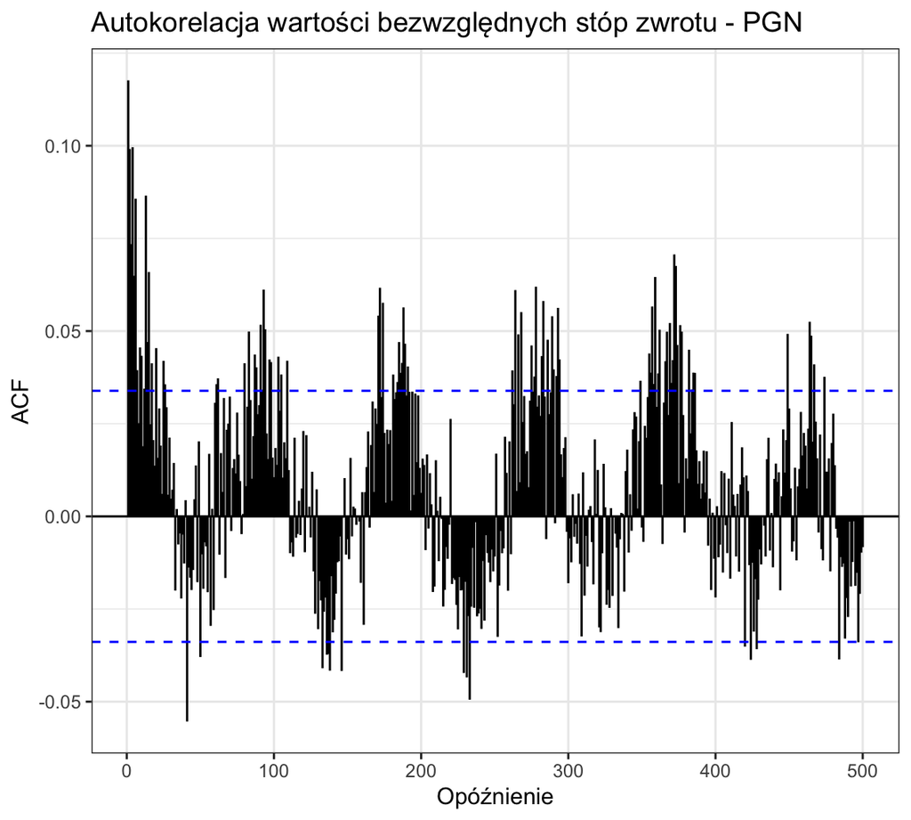

# 4 Usuwanie sezonowości

Usuwanie zmienności śróddziennej sezonowości może być dokonane relatywnie prostą metodą. Założywszy stałość zmienności dziennej należy podzielić poszczególne stopy zwrotu przez odpowiadające im przekrojowe średnie z wartości bezwzględnych. Innymi słowy każdą 5-minutową stopę zwrotu przyporządkowaną do danej godziny należy podzielić przez średnią z wartości bezwzględnych wszystkich 5-minutowych wartości stóp zwrotu przyporządkowanych do tej godziny.

```r
rates_pge_new <- left_join(rates_pge, mean_rates_abs_pge, by = "Time") %>%
  select("Date", "Time", "Rate", "Mean")
rates_pge_new$Rate <- rates_pge_new$Rate / rates_pge_new$Mean

rates_pgn_new <- left_join(rates_pgn, mean_rates_abs_pgn, by = "Time") %>%
  select("Date", "Time", "Rate", "Mean")
rates_pgn_new$Rate <- rates_pgn_new$Rate / rates_pgn_new$Mean
```

Po zastosowaniu tej metody ponownie zbadano autokorelacje wartości bezwzględnych tak zmodyfikowanych stóp zwrotu. Sezonowość przestała być widoczna, a wahania wartości współczynnika autokorelacji zmniejszyły się. Można stwierdzić, iż zaproponowana metoda okazała się skuteczna w usuwaniu sezonowości w zmienności.

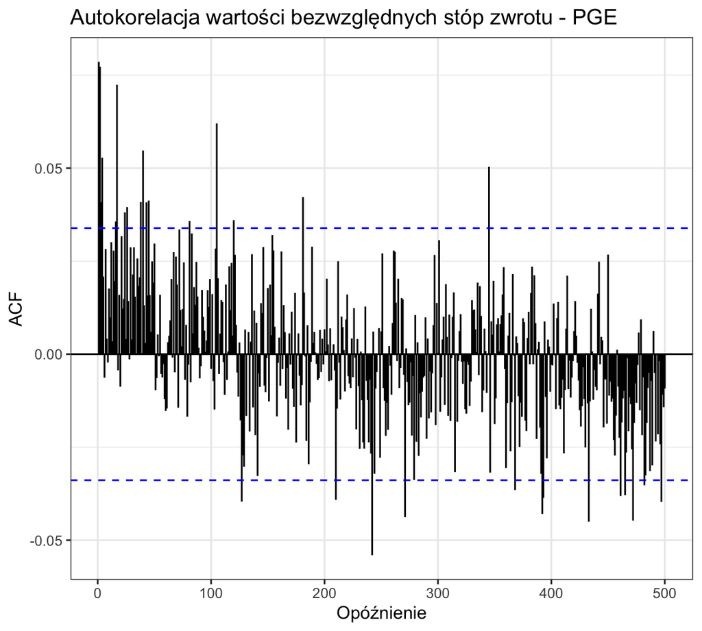

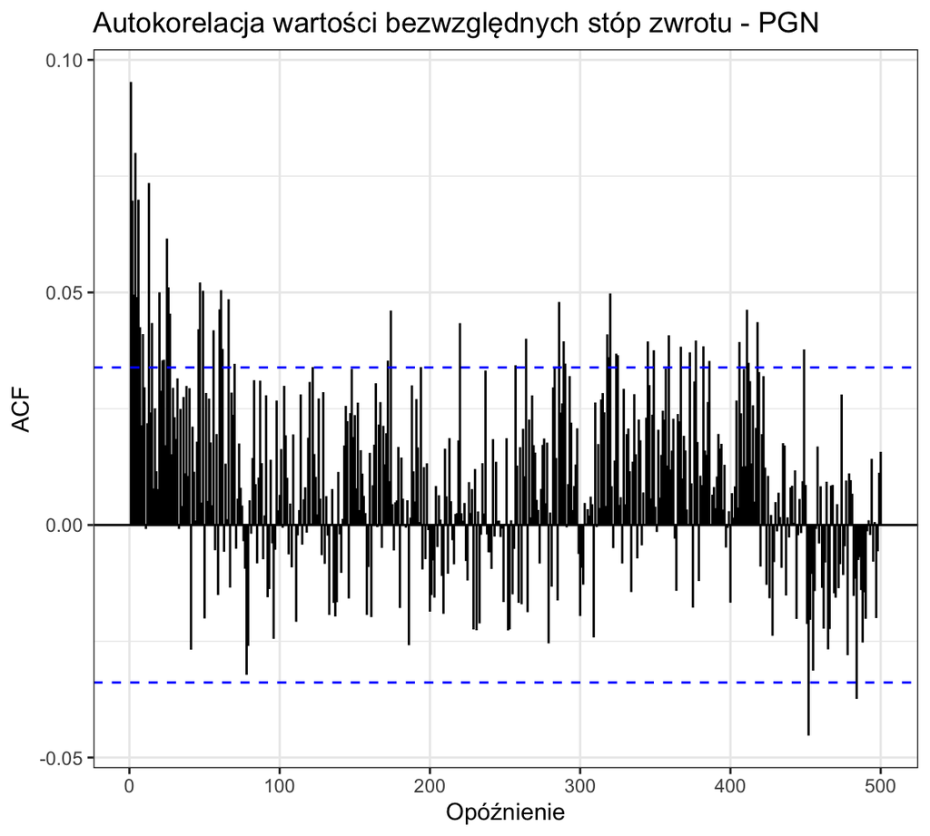

# 5 Podsumowanie

W pracy zbadano intensywność obrotu akcjami wybranych spółek giełdowych, tj. PGE i PGN na przestrzeni sesji giełdowej. Zarówno analiza przekrojowych średnich stóp zwrotu jak i średniego zlogarytmowanego wolumenu pozwala stwierdzić, iż największa intensywność obrotu akcjami występuje na początku i na końcu sesji giełdowej. Okres od godziny 11:00 do 14:00 można określić jako najbardziej spokojny, gdzie transakcje opiewają na mniejsze wartości liczby wolumenów.

Następnie dla wykrytej śróddziennej sezonowości zmienności zaproponowano stosunkowo prostą metodę do jej usunięcia. Sama śróddzienną sezonowość była bardzo zauważalna podczas analizy przekrojowych średnich z wartości bezwzględnych 5-minutowych stóp zwrotu oraz ich autokorelacji. Najwyższe wartości ACF były odnotowane dla początkowych opóźnień, następnie dla opóźnień w okolicach 93 okresu i wielokrotności 93 okresu. Świadczy to o występowaniu śróddziennej sezonowości danych. Wspomnianą sezonowość udało się usunąć wykorzystując relatywnie prostą metodę polegającą na tym, iż podzielono poszczególne stopy zwrotu przez odpowiadające im przekrojowe średnie z wartości bezwzględnych.